```r
# Run data wrangling files first ####
# Run limited service script
source(file = "limited_serv_wrangling.R", local = wrangled <- new.env())
# Run all industries script
source(file = "all_industries_data_wrangling.R", local = wrangled)
library(dplyr)
```

```r
# getwd()
```

# Joining all industries and limited service

```r
joined <- new.env()
joined$data <- full_join(
  x = wrangled$min_wage$limited_increase,
  y = wrangled$all_ind_combined$gather) |>
  mutate(
    proportion_limited = emplvl_limited / emplvl_all) |>
  # filter(proportion_limited > 0 & !is.infinite(proportion_limited)) |>
  na.omit() |>
  mutate(
    area_fips = factor(area_fips)
  ) %>%
  filter(emplvl_limited > 0)
```

# Diagnostics

# Checking if there are any zeros

# range(joined$data$proportion_limited)

# range(joined$data$emplvl_all)

# range(joined$data$emplvl_limited)

# any(joined$data[,-22:-23] == 0) # # Checking how many times each county appears # table(joined$data$year, joined$data$area_title)

# write_csv(x = joined$data, file = "joined_data.csv") # joined <- new.env() # joined$data <- read_csv(file = “joined_data.csv”)

# Creating dummies

# library(fastDummies)

```r
#Setting up for 2011-2012

data_2011_2012 <- joined$data |>
  filter(year_decimal %in% seq(2011.5,2012.5, by = 1/12)) |>
  mutate(year = as.factor(year))

#Regression for 2011-2012

model_2011_2012 <- lm(formula = emplvl_limited ~ state * year + emplvl_all,
   data = data_2011_2012)

model_2011_2012
```

```
##
## Call:
## lm(formula = emplvl_limited ~ state * year + emplvl_all, data = data_2011_2012)
##
## Coefficients:
##      (Intercept)           stateMO          year2012        emplvl_all
##        -236.6024          629.1915          127.2332            0.0307
## stateMO:year2012
##        -110.2617
```

```r
#Setting up for 2012-2013

data_2012_2013 <- joined$data |>
  filter(year_decimal %in% seq(2012.5,2013.5, by = 1/12)) |>
  mutate(year = as.factor(year)) #|>
  # dummy_columns(
  #   select_columns = c('year_decimal', 'state'),
  #   remove_first_dummy = TRUE,
  # ) |>
  # rename(post = year_2013, treat = state_MO)
```

# write_csv(x = data_2012_2013, file = “data_2012_2013.csv”)

# data_2012_2013 <- read_csv(file = “data_2012_2013.csv”)

# # Checking if there are any zeros

# range(data_2012_2013$proportion_limited) # range(data_2012_2013$emplvl_all)

# range(data_2012_2013$emplvl_limited) # any(data_2012_2013[,-22:-23] == 0) # # Checking how many times each county appears # table(data_2012_2013$year, data_2012_2013$area_title)

# ####################

# #######D-i-D

# ####################

# models <- new.env()

felm_proportion <- felm(proportion_limited ~ state * year, data = data_2012_2013)

summary(felm_proportion)

felm_all <- lm(emplvl_limited ~ emplvl_all*year*state, data = data_2012_2013)

summary(felm_all)

felm_cont_treatment <- felm(emplvl_limited ~ min_wage + emplvl_all | area_title + date, data = joined$data)

# summary(felm_cont_treatment)

lm_cont_treatment <- lm(emplvl_limited ~ min_wage + emplvl_all + area_title + factor(date), data = joined$data)

# summary(lm_cont_treatment)

# try using this with felm: xactDOF = TRUE)

# Trying without fixed effects

lm_proportion <- lm(proportion_limited ~ treat * post, data = data_2012_2013)

summary(lm_proportion)

```r
#Regression for 2012-2013

model_2012_2013 <- lm(formula = emplvl_limited ~ state * year + emplvl_all,
   data = data_2012_2013)

model_2012_2013
```

```
##
## Call:
## lm(formula = emplvl_limited ~ state * year + emplvl_all, data = data_2012_2013)
##
## Coefficients:
##      (Intercept)           stateMO          year2013        emplvl_all
##       -163.55541         549.00101          23.99582           0.03142
## stateMO:year2013
##          6.80687
```

```r
# Setting up for 2013 - 2014

data_2013_2014 <- joined$data |>
  filter(year_decimal %in% seq(2013.5,2014.5, by = 1/12)) |>
  mutate(year = as.factor(year))

#Regression for 2013 - 2014

model_2013_2014 <- lm(formula = emplvl_limited ~ state * year + emplvl_all,
   data = data_2013_2014)

model_2013_2014
```

```
##
## Call:
## lm(formula = emplvl_limited ~ state * year + emplvl_all, data = data_2013_2014)
##
## Coefficients:
##      (Intercept)           stateMO          year2014        emplvl_all
##       -192.22233         596.56774         -32.31529           0.03182
## stateMO:year2014
##         94.41454
```

```r
# Setting up for 2014 - 2015

data_2014_2015 <- joined$data |>
  filter(year_decimal %in% seq(2014.5,2015.5, by = 1/12)) |>
  mutate(year = as.factor(year))

#Regression for 2014 - 2015

model_2014_2015 <- lm(formula = emplvl_limited ~ state * year + emplvl_all,
   data = data_2014_2015)

model_2014_2015
```

```
##
## Call:
## lm(formula = emplvl_limited ~ state * year + emplvl_all, data = data_2014_2015)
##
## Coefficients:
##      (Intercept)           stateMO          year2015        emplvl_all
##       -253.57132         695.80845          11.11175           0.03191
## stateMO:year2015
##         75.99156
```

```r
# Setting up for 2015 - 2016

data_2015_2016 <- joined$data |>
  filter(year_decimal %in% seq(2015.5,2016.5, by = 1/12)) |>
  mutate(year = as.factor(year))

#Regression for 2015 - 2016

model_2015_2016 <- lm(formula = emplvl_limited ~ state * year + emplvl_all,
   data = data_2015_2016)

model_2015_2016
```

```
##
## Call:
## lm(formula = emplvl_limited ~ state * year + emplvl_all, data = data_2015_2016)
##
## Coefficients:
##      (Intercept)           stateMO          year2016        emplvl_all
##       -312.90916         824.37573         133.01575           0.03246
## stateMO:year2016
##       -102.88055
```

```r
# Setting up for 2016 - 2017

data_2016_2017 <- joined$data |>
  filter(year_decimal %in% seq(2016.5,2017.5, by = 1/12)) |>
  mutate(year = as.factor(year))

#Regression for 2016 - 2017

model_2016_2017 <- lm(formula = emplvl_limited ~ state * year + emplvl_all,
   data = data_2016_2017)

model_2016_2017
```

```
##
## Call:
## lm(formula = emplvl_limited ~ state * year + emplvl_all, data = data_2016_2017)
##
## Coefficients:
##      (Intercept)           stateMO          year2017        emplvl_all
##       -237.26757         716.77097          66.42958           0.03276
## stateMO:year2017
##          7.61472
```

```r
# Setting up for 2017 - 2018

data_2017_2018 <- joined$data |>
  filter(year_decimal %in% seq(2017.5,2018.5, by = 1/12)) |>
  mutate(year = as.factor(year))

#Regression for 2017 - 2018

model_2017_2018 <- lm(formula = emplvl_limited ~ state * year + emplvl_all,
   data = data_2017_2018)

model_2017_2018
```

```
##
## Call:
## lm(formula = emplvl_limited ~ state * year + emplvl_all, data = data_2017_2018)
##
## Coefficients:
##      (Intercept)           stateMO          year2018        emplvl_all
##       -168.57196         731.10541          23.47235           0.03204
## stateMO:year2018
##        -78.05045
```

```r
# Setting up for 2018 - 2019

data_2018_2019 <- joined$data |>
  filter(year_decimal %in% seq(2018.5,2019.5, by = 1/12)) |>
  mutate(year = as.factor(year))

#Regression for 2018 - 2019

model_2018_2019 <- lm(formula = emplvl_limited ~ state * year + emplvl_all,
   data = data_2018_2019)

model_2018_2019
```

```
##
## Call:
## lm(formula = emplvl_limited ~ state * year + emplvl_all, data = data_2018_2019)
##
## Coefficients:
##      (Intercept)           stateMO          year2019        emplvl_all
##        -146.2029          671.6272           44.1102            0.0313
## stateMO:year2019
##           3.5421
```

```r
# Setting up for 2019 - 2020

data_2019_2020 <- joined$data |>
  filter(year_decimal %in% seq(2019.5,2020.5, by = 1/12)) |>
  mutate(year = as.factor(year))

#Regression for 2019 - 2020

model_2019_2020 <- lm(formula = emplvl_limited ~ state * year + emplvl_all,
   data = data_2019_2020)

model_2019_2020
```

```
##
## Call:
## lm(formula = emplvl_limited ~ state * year + emplvl_all, data = data_2019_2020)
##
## Coefficients:
##      (Intercept)           stateMO          year2020        emplvl_all
##       -132.29968         698.26594          -6.16743           0.03176
## stateMO:year2020
##         28.62215
```

```r
# Setting up for 2020 - 2021

data_2020_2021 <- joined$data |>
  filter(year_decimal %in% seq(2020.5,2021.5, by = 1/12)) |>
  mutate(year = as.factor(year))

#Regression for 2020 - 2021

model_2020_2021 <- lm(formula = emplvl_limited ~ state * year + emplvl_all,
   data = data_2020_2021)

model_2020_2021
```

```
##
## Call:
## lm(formula = emplvl_limited ~ state * year + emplvl_all, data = data_2020_2021)
##
## Coefficients:
##      (Intercept)           stateMO          year2021        emplvl_all
##       -148.37479         807.29653         -29.56850           0.03162
## stateMO:year2021
##          4.47185
```

```r
# Setting up for 2021 - 2022

data_2021_2022 <- joined$data |>
  filter(year_decimal %in% seq(2021.5,2022.5, by = 1/12)) |>
  mutate(year = as.factor(year))

#Regression for 2021 - 2022

model_2021_2022 <- lm(formula = emplvl_limited ~ state * year + emplvl_all,
   data = data_2021_2022)

model_2021_2022
```

```
##
## Call:
## lm(formula = emplvl_limited ~ state * year + emplvl_all, data = data_2021_2022)
##
## Coefficients:
##      (Intercept)           stateMO          year2022        emplvl_all
##       -206.68180         850.16261          24.89593           0.03113
## stateMO:year2022
##         37.83004
```

```r
confint_model_2011_2012 <- confint(model_2011_2012)["stateMO:year2012",]

confint_model_2012_2013 <- confint(model_2012_2013)["stateMO:year2013",]

confint_model_2013_2014 <- confint(model_2013_2014)
confint_model_2014_2015 <- confint(model_2014_2015)
confint_model_2015_2016 <- confint(model_2015_2016)
confint_model_2016_2017 <- confint(model_2016_2017)
confint_model_2017_2018 <- confint(model_2017_2018)
confint_model_2018_2019 <- confint(model_2018_2019)
confint_model_2019_2020 <- confint(model_2019_2020)
confint_model_2020_2021 <- confint(model_2020_2021)
confint_model_2021_2022 <- confint(model_2021_2022)
```

```r
confints <- rbind(
"m_2012" = confint(model_2011_2012)["stateMO:year2012",], "m_2013" = confint(model_2012_2013)["stateMO:year2013",], "m_2014" = confint(model_2013_2014)["stateMO:year2014",], "m_2015" = confint(model_2014_2015)["stateMO:year2015",],
"m_2016" = confint(model_2015_2016)["stateMO:year2016",],
"m_2017" = confint(model_2016_2017)["stateMO:year2017",],
"m_2018" = confint(model_2017_2018)["stateMO:year2018",],
"m_2019" = confint(model_2018_2019)["stateMO:year2019",],
"m_2020" = confint(model_2019_2020)["stateMO:year2020",],
"m_2021" = confint(model_2020_2021)["stateMO:year2021",],
"m_2022" = confint(model_2021_2022)["stateMO:year2022",]
) %>% as.data.frame() %>%
  mutate(year = 2012:2022)
```

```r
# Compile coefficients into dataframe for visualizations

library(broom)

tidy_model_2011_2012 <- tidy(model_2011_2012) %>%
  filter(term %in% "stateMO:year2012") %>%
           select(term,estimate)

tidy_model_2012_2013 <- tidy(model_2012_2013) %>%
  filter(term %in% "stateMO:year2013") %>%
           select(term,estimate)


tidy_model_2013_2014 <- tidy(model_2013_2014) %>%
  filter(term %in% "stateMO:year2014") %>%
           select(term,estimate)

tidy_model_2014_2015 <- tidy(model_2014_2015) %>%
  filter(term %in% "stateMO:year2015") %>%
           select(term,estimate)

tidy_model_2015_2016 <- tidy(model_2015_2016) %>%
  filter(term %in% "stateMO:year2016") %>%
           select(term,estimate)

tidy_model_2016_2017 <- tidy(model_2016_2017) %>%
  filter(term %in% "stateMO:year2017") %>%
           select(term,estimate)

tidy_model_2017_2018 <- tidy(model_2017_2018) %>%
  filter(term %in% "stateMO:year2018") %>%
           select(term,estimate)

tidy_model_2018_2019 <- tidy(model_2018_2019) %>%
  filter(term %in% "stateMO:year2019") %>%
           select(term,estimate)

tidy_model_2019_2020 <- tidy(model_2019_2020) %>%
  filter(term %in% "stateMO:year2020") %>%
           select(term,estimate)

tidy_model_2020_2021 <- tidy(model_2020_2021) %>%
  filter(term %in% "stateMO:year2021") %>%
           select(term,estimate)

tidy_model_2021_2022 <- tidy(model_2021_2022) %>%
  filter(term %in% "stateMO:year2022") %>%
           select(term,estimate)

#Adding all rows into one table

Coefficients_visualizations_table <- bind_rows("Model 2011 - 2012" = tidy_model_2011_2012, "Model 2012 - 2013" = tidy_model_2012_2013, "Model 2013 - 2014" = tidy_model_2013_2014, "Model 2014 - 2015" = tidy_model_2014_2015, "Model 2015 - 2016" = tidy_model_2015_2016, "Model 2016 - 2017" = tidy_model_2016_2017, "Model 2017 - 2018" = tidy_model_2017_2018, "Model 2018 - 2019" = tidy_model_2018_2019, "Model 2019 - 2020" = tidy_model_2019_2020, "Model 2020 - 2021" = tidy_model_2020_2021, "Model 2021 - 2022" = tidy_model_2021_2022) %>% rename( state_year_coefficient = estimate, year = term)

#Changing into values into the years

Coefficients_visualizations_table <- Coefficients_visualizations_table %>%
  mutate(year = case_when( year == "stateMO:year2012"~ 2012,year == "stateMO:year2013" ~ 2013, year == "stateMO:year2014" ~ 2014, year == "stateMO:year2015" ~ 2015, year == "stateMO:year2016" ~ 2016, year == "stateMO:year2017" ~ 2017, year == "stateMO:year2018" ~ 2018, year == "stateMO:year2019" ~ 2019, year == "stateMO:year2020" ~ 2020, year == "stateMO:year2021" ~ 2021, year == "stateMO:year2022" ~ 2022
          ))

# Add min wage data into the table

Coefficients_visualizations_table <- Coefficients_visualizations_table %>%
  mutate(mw_increase = c(0 , 0.10 , 0.15 , 0.15 , 0 , 0.05 , 0.15 , 0.75 , 0.85 , 0.85 , 0.85 ))

write.csv(Coefficients_visualizations_table, file = "Coefficients_visualizations_table")

#Join Confints into the Coefficients Visualizations Table

Master_Table <- left_join(
x = Coefficients_visualizations_table,
y = confints,
by = "year"
) %>%
  rename(lwr = "2.5 %", upr = "97.5 %")
```

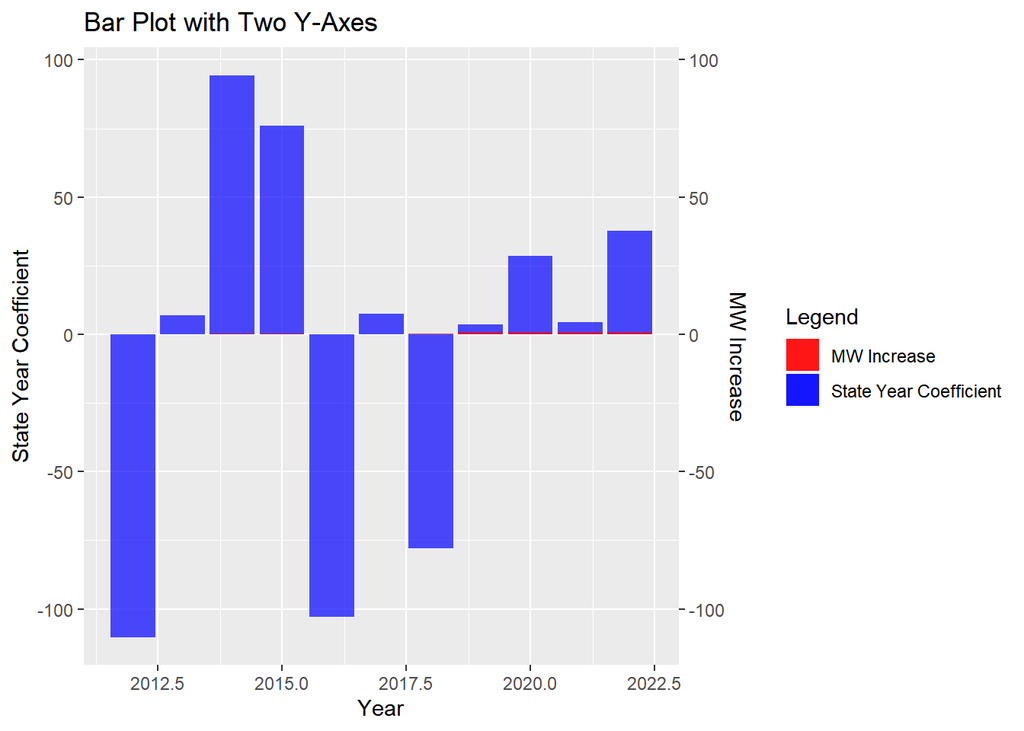

```r
#Coefficient and min wage plot

ggplot(Coefficients_visualizations_table, aes(x = year)) + geom_col(aes(y = state_year_coefficient, fill = "State Year Coefficient" ) , position = "dodge", alpha = 0.7) + geom_col(aes(y= mw_increase, fill = "MW Increase"), position = "dodge", alpha = 0.7) +
labs(title = "Bar Plot with Two Y-Axes",
       x = "Year",
       y = "Values", fill= "Legend") +
 scale_fill_manual(values = c("State Year Coefficient" = "blue", "MW Increase" = "red")) +
  scale_y_continuous(
    name = "State Year Coefficient",
    sec.axis = sec_axis(~., name = "MW Increase")
  )
```

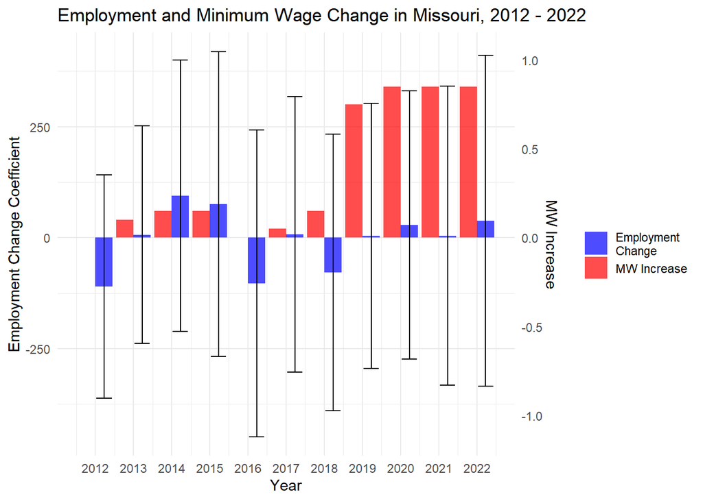

```r
# Reshape the data into a longer format
reshaped_data <- Master_Table %>%
  mutate(mw_increase = mw_increase*(1/0.0025)) %>%
  pivot_longer(
    cols = c(state_year_coefficient, mw_increase),
    names_to = "Variable",
    values_to = "Value"
  )

# Plotting the reshaped data
col_plot <- ggplot(reshaped_data, aes(x = year, y = Value, fill = Variable)) +
  geom_col(position = "dodge", alpha = 0.7) +
  geom_errorbar(aes(ymin= lwr, ymax= upr),
                position = position_nudge( x = 0.23), width = 0.4) +
  labs(
    title = "Employment and Minimum Wage Change in Missouri, 2012 - 2022",
    x = "Year",
    y = "Values",
    fill = " "
  ) +
  scale_fill_manual(values = c("state_year_coefficient" = "blue", "mw_increase" = "red"),
                    breaks = c("state_year_coefficient", "mw_increase"),
                    labels = c("Employment\nChange", "MW Increase")) +
  scale_y_continuous(
    name = "Employment Change Coefficient",
    sec.axis = sec_axis(~. * .0025, name = "MW Increase")
  ) +
  theme_minimal() +
  scale_x_continuous(breaks = 2012:2022)

col_plot
```

```r
ggsave(filename = "Column_Plot.png", plot = col_plot, dpi = "retina", width = 10.4, height = 4.81)
```

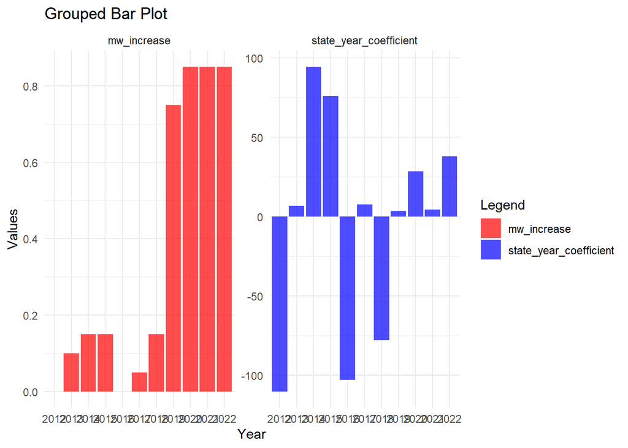

```r
library(ggplot2)
library(dplyr)

# Set your desired scaling factor
scaling_factor <- 0.1

# Create a long format of the data for ggplot
plot_data <- Coefficients_visualizations_table %>%
  pivot_longer(cols = c(state_year_coefficient, mw_increase),
               names_to = "variable",
               values_to = "value")

# Create a grouped bar plot
ggplot(plot_data, aes(x = as.factor(year), fill = variable, y = value)) +
  geom_col(position = "dodge", alpha = 0.7) +
  labs(
    title = "Grouped Bar Plot",
    x = "Year",
    y = "Values",
    fill = "Legend"
  ) +
  scale_fill_manual(values = c("state_year_coefficient" = "blue", "mw_increase" = "red")) +
  facet_wrap(~ variable, scales = "free_y") +
  theme_minimal()
```

```r
#Regression Summaries for Table

summary(model_2011_2012)
```

```
##
## Call:
## lm(formula = emplvl_limited ~ state * year + emplvl_all, data = data_2011_2012)
##
## Residuals:
##      Min       1Q   Median       3Q      Max
## -1378.20  -259.06    11.75   253.85  1041.96
##
## Coefficients:
##                    Estimate Std. Error t value Pr(>|t|)
## (Intercept)      -2.366e+02  7.564e+01  -3.128  0.00204 **
## stateMO           6.292e+02  9.366e+01   6.718 2.09e-10 ***
## year2012          1.272e+02  9.886e+01   1.287  0.19966
## emplvl_all        3.070e-02  3.469e-04  88.510  < 2e-16 ***
## stateMO:year2012 -1.103e+02  1.276e+02  -0.864  0.38871
## ---
## Signif. codes:  0 '***' 0.001 '**' 0.01 '*' 0.05 '.' 0.1 ' ' 1
##
## Residual standard error: 435.3 on 190 degrees of freedom
## Multiple R-squared:  0.9765, Adjusted R-squared:  0.976
## F-statistic:  1971 on 4 and 190 DF,  p-value: < 2.2e-16
```

```r
summary(model_2012_2013)
```

```
##
## Call:
## lm(formula = emplvl_limited ~ state * year + emplvl_all, data = data_2012_2013)
##
## Residuals:
##      Min       1Q   Median       3Q      Max
## -1123.55  -243.38   -25.84   244.83  1208.64
##
## Coefficients:
##                    Estimate Std. Error t value Pr(>|t|)
## (Intercept)      -1.636e+02  7.374e+01  -2.218   0.0277 *
## stateMO           5.490e+02  9.130e+01   6.013 9.14e-09 ***
## year2013          2.400e+01  9.636e+01   0.249   0.8036
## emplvl_all        3.142e-02  3.305e-04  95.069  < 2e-16 ***
## stateMO:year2013  6.807e+00  1.244e+02   0.055   0.9564
## ---
## Signif. codes:  0 '***' 0.001 '**' 0.01 '*' 0.05 '.' 0.1 ' ' 1
##
## Residual standard error: 424.3 on 190 degrees of freedom
## Multiple R-squared:  0.9795, Adjusted R-squared:  0.9791
## F-statistic:  2270 on 4 and 190 DF,  p-value: < 2.2e-16
```

```r
summary(model_2013_2014)
```

```
##
## Call:
## lm(formula = emplvl_limited ~ state * year + emplvl_all, data = data_2013_2014)
##
## Residuals:
##     Min      1Q  Median      3Q     Max
## -1332.2  -286.7  -139.9   309.9  1573.3
##
## Coefficients:
##                    Estimate Std. Error t value Pr(>|t|)
## (Intercept)      -1.922e+02  9.175e+01  -2.095   0.0375 *
## stateMO           5.966e+02  1.135e+02   5.254 3.96e-07 ***
## year2014         -3.232e+01  1.198e+02  -0.270   0.7877
## emplvl_all        3.182e-02  4.030e-04  78.967  < 2e-16 ***
## stateMO:year2014  9.441e+01  1.547e+02   0.610   0.5424
## ---
## Signif. codes:  0 '***' 0.001 '**' 0.01 '*' 0.05 '.' 0.1 ' ' 1
##
## Residual standard error: 527.6 on 190 degrees of freedom
## Multiple R-squared:  0.9706, Adjusted R-squared:   0.97
## F-statistic:  1568 on 4 and 190 DF,  p-value: < 2.2e-16
```

```r
summary(model_2014_2015)
```

```
##
## Call:
## lm(formula = emplvl_limited ~ state * year + emplvl_all, data = data_2014_2015)
##
## Residuals:
##     Min      1Q  Median      3Q     Max
## -1510.9  -314.4   -95.9   331.1  1636.3
##
## Coefficients:
##                    Estimate Std. Error t value Pr(>|t|)
## (Intercept)      -2.536e+02  1.033e+02  -2.456    0.015 *
## stateMO           6.958e+02  1.277e+02   5.448 1.56e-07 ***
## year2015          1.111e+01  1.348e+02   0.082    0.934
## emplvl_all        3.191e-02  4.424e-04  72.128  < 2e-16 ***
## stateMO:year2015  7.599e+01  1.740e+02   0.437    0.663
## ---
## Signif. codes:  0 '***' 0.001 '**' 0.01 '*' 0.05 '.' 0.1 ' ' 1
##
## Residual standard error: 593.4 on 190 degrees of freedom
## Multiple R-squared:  0.965,  Adjusted R-squared:  0.9643
## F-statistic:  1310 on 4 and 190 DF,  p-value: < 2.2e-16
```

```r
summary(model_2015_2016)
```

```
##
## Call:
## lm(formula = emplvl_limited ~ state * year + emplvl_all, data = data_2015_2016)
##
## Residuals:
##      Min       1Q   Median       3Q      Max
## -1745.90  -376.62    42.17   371.35  1632.88
##
## Coefficients:
##                    Estimate Std. Error t value Pr(>|t|)
## (Intercept)      -3.129e+02  1.038e+02  -3.014  0.00293 **
## stateMO           8.244e+02  1.284e+02   6.420 1.06e-09 ***
## year2016          1.330e+02  1.355e+02   0.982  0.32757
## emplvl_all        3.246e-02  4.366e-04  74.333  < 2e-16 ***
## stateMO:year2016 -1.029e+02  1.750e+02  -0.588  0.55719
## ---
## Signif. codes:  0 '***' 0.001 '**' 0.01 '*' 0.05 '.' 0.1 ' ' 1
##
## Residual standard error: 596.6 on 190 degrees of freedom
## Multiple R-squared:  0.967,  Adjusted R-squared:  0.9663
## F-statistic:  1393 on 4 and 190 DF,  p-value: < 2.2e-16
```

```r
summary(model_2016_2017)
```

```
##
## Call:
## lm(formula = emplvl_limited ~ state * year + emplvl_all, data = data_2016_2017)
##
## Residuals:
##      Min       1Q   Median       3Q      Max
## -1382.61  -332.53    80.49   295.62  1443.59
##
## Coefficients:
##                    Estimate Std. Error t value Pr(>|t|)
## (Intercept)      -2.373e+02  9.339e+01  -2.541   0.0119 *
## stateMO           7.168e+02  1.155e+02   6.205 3.35e-09 ***
## year2017          6.643e+01  1.219e+02   0.545   0.5865
## emplvl_all        3.276e-02  3.875e-04  84.541  < 2e-16 ***
## stateMO:year2017  7.615e+00  1.574e+02   0.048   0.9615
## ---
## Signif. codes:  0 '***' 0.001 '**' 0.01 '*' 0.05 '.' 0.1 ' ' 1
##
## Residual standard error: 536.8 on 190 degrees of freedom
## Multiple R-squared:  0.9743, Adjusted R-squared:  0.9737
## F-statistic:  1799 on 4 and 190 DF,  p-value: < 2.2e-16
```

```r
summary(model_2017_2018)
```

```
##
## Call:
## lm(formula = emplvl_limited ~ state * year + emplvl_all, data = data_2017_2018)
##
## Residuals:
##      Min       1Q   Median       3Q      Max
## -1408.74  -368.25    67.68   265.23  1608.09
##
## Coefficients:
##                    Estimate Std. Error t value Pr(>|t|)
## (Intercept)      -1.686e+02  9.361e+01  -1.801   0.0733 .
## stateMO           7.311e+02  1.158e+02   6.314 1.88e-09 ***
## year2018          2.347e+01  1.222e+02   0.192   0.8479
## emplvl_all        3.204e-02  3.825e-04  83.770  < 2e-16 ***
## stateMO:year2018 -7.805e+01  1.578e+02  -0.495   0.6214
## ---
## Signif. codes:  0 '***' 0.001 '**' 0.01 '*' 0.05 '.' 0.1 ' ' 1
##
## Residual standard error: 538.1 on 190 degrees of freedom
## Multiple R-squared:  0.9738, Adjusted R-squared:  0.9732
## F-statistic:  1765 on 4 and 190 DF,  p-value: < 2.2e-16
```

```r
summary(model_2018_2019)
```

```
##
## Call:
## lm(formula = emplvl_limited ~ state * year + emplvl_all, data = data_2018_2019)
##
## Residuals:
##     Min      1Q  Median      3Q     Max
## -1302.1  -425.4   125.8   373.5  1256.1
##
## Coefficients:
##                    Estimate Std. Error t value Pr(>|t|)
## (Intercept)      -1.462e+02  8.971e+01  -1.630    0.105
## stateMO           6.716e+02  1.110e+02   6.051 7.52e-09 ***
## year2019          4.411e+01  1.171e+02   0.377    0.707
## emplvl_all        3.130e-02  3.625e-04  86.354  < 2e-16 ***
## stateMO:year2019  3.542e+00  1.512e+02   0.023    0.981
## ---
## Signif. codes:  0 '***' 0.001 '**' 0.01 '*' 0.05 '.' 0.1 ' ' 1
##
## Residual standard error: 515.8 on 190 degrees of freedom
## Multiple R-squared:  0.9753, Adjusted R-squared:  0.9748
## F-statistic:  1876 on 4 and 190 DF,  p-value: < 2.2e-16
```

```r
summary(model_2019_2020)
```

```
##
## Call:
## lm(formula = emplvl_limited ~ state * year + emplvl_all, data = data_2019_2020)
##
## Residuals:
##     Min      1Q  Median      3Q     Max
## -1704.0  -431.7   108.5   358.8  1431.2
##
## Coefficients:
##                    Estimate Std. Error t value Pr(>|t|)
## (Intercept)      -1.323e+02  9.090e+01  -1.455    0.147
## stateMO           6.983e+02  1.122e+02   6.224 3.03e-09 ***
## year2020         -6.167e+00  1.184e+02  -0.052    0.959
## emplvl_all        3.176e-02  3.743e-04  84.843  < 2e-16 ***
## stateMO:year2020  2.862e+01  1.529e+02   0.187    0.852
## ---
## Signif. codes:  0 '***' 0.001 '**' 0.01 '*' 0.05 '.' 0.1 ' ' 1
##
## Residual standard error: 521.3 on 190 degrees of freedom
## Multiple R-squared:  0.9745, Adjusted R-squared:  0.9739
## F-statistic:  1812 on 4 and 190 DF,  p-value: < 2.2e-16
```

```r
summary(model_2020_2021)
```

```
##
## Call:
## lm(formula = emplvl_limited ~ state * year + emplvl_all, data = data_2020_2021)
##
## Residuals:
##      Min       1Q   Median       3Q      Max
## -1476.92  -505.88    71.44   426.61  1399.53
##
## Coefficients:
##                    Estimate Std. Error t value Pr(>|t|)
## (Intercept)      -1.484e+02  1.014e+02  -1.464    0.145
## stateMO           8.073e+02  1.254e+02   6.438 9.66e-10 ***
## year2021         -2.957e+01  1.323e+02  -0.223    0.823
## emplvl_all        3.162e-02  4.264e-04  74.156  < 2e-16 ***
## stateMO:year2021  4.472e+00  1.709e+02   0.026    0.979
## ---
## Signif. codes:  0 '***' 0.001 '**' 0.01 '*' 0.05 '.' 0.1 ' ' 1
##
## Residual standard error: 582.7 on 190 degrees of freedom
## Multiple R-squared:  0.9669, Adjusted R-squared:  0.9662
## F-statistic:  1388 on 4 and 190 DF,  p-value: < 2.2e-16
```

```r
summary(model_2021_2022)
```

```
##
## Call:
## lm(formula = emplvl_limited ~ state * year + emplvl_all, data = data_2021_2022)
##
## Residuals:
##     Min      1Q  Median      3Q     Max
## -1752.3  -519.3   151.8   396.1  1595.8
##
## Coefficients:
##                    Estimate Std. Error t value Pr(>|t|)
## (Intercept)      -2.067e+02  1.119e+02  -1.847   0.0664 .
## stateMO           8.502e+02  1.385e+02   6.137  4.8e-09 ***
## year2022          2.490e+01  1.462e+02   0.170   0.8650
## emplvl_all        3.113e-02  4.556e-04  68.330  < 2e-16 ***
## stateMO:year2022  3.783e+01  1.888e+02   0.200   0.8414
## ---
## Signif. codes:  0 '***' 0.001 '**' 0.01 '*' 0.05 '.' 0.1 ' ' 1
##
## Residual standard error: 643.7 on 190 degrees of freedom
## Multiple R-squared:  0.9613, Adjusted R-squared:  0.9605
## F-statistic:  1180 on 4 and 190 DF,  p-value: < 2.2e-16
```

```r
library(stargazer)
table_models <- list(model_2011_2012, model_2012_2013, model_2013_2014, model_2014_2015, model_2015_2016, model_2016_2017, model_2017_2018, model_2018_2019, model_2019_2020, model_2020_2021, model_2021_2022)
```

```r
model_names <- c("Model 2011-2012", "Model 2012-2013", "Model 2013-2014", "Model 2014-2015", "Model 2015-2016", "Model 2016-2017", "Model 2017-2018", "Model 2018-2019", "Model 2019-2020", "Model 2020-2021", "Model 2021-2022")

# Extract coefficients for each model
coefficients_list <- lapply(table_models, coef)

# Create a new list to store consolidated coefficients
consolidated_coefficients <- list()

# Loop through each year
for (year in unique(gsub(".*year(.*)", "\\1", names(coefficients_list[[1]])))) {
  # Extract coefficients for the specific year
  year_coefficients <- lapply(coefficients_list, function(model) model[grep(paste0("year", year), names(model))])

  # Consolidate coefficients for the specific year
  consolidated_coefficients[[year]] <- do.call(cbind, year_coefficients)
}
```

```r
# Customize stargazer options
stargazer(
  table_models[[1]],
  title = "Regression Results",
  type = 'latex',
  align = TRUE,                  # Align coefficient names to the left
  dep.var.caption = "Dependent variable: \\textbf{emplvl\\_limited}",  # Bold dependent variable in the caption
  column.labels = model_names,   # Model labels
  covariate.labels = names(consolidated_coefficients[[1]]),  # Custom order of variables
  digits = 3,                    # Number of decimal places
  star.cutoffs = c(0.1, 0.05, 0.01),  # Customize significance stars
  notes = "\\textit{Note:} $^{*}p<0.1; ^{**}p<0.05; ^{***}p<0.01",  # Custom note
  omit = names(consolidated_coefficients[[1]])[-1]  # Omit redundant coefficients
)
```

[output not shown]

```r
# Trying with the three year pairs instead

table_models_2 <- list(model_2011_2012, model_2012_2013, model_2013_2014)


# stargazer(table_models_2)
```